# **Unsupervised Learning Project: AllLife Bank Customer Segmentation**

# **Marks: 30**

Welcome to the project on Unsupervised Learning. We will be using **Credit Card Customer Data** for this project.

## **Context**

**AllLife Bank wants to focus on its credit card customer base** in the next financial year. They have been advised by their marketing research team, that the penetration in the market can be improved. Based on this input, the marketing team proposes to run personalized campaigns to target new customers as well as upsell to existing customers.

Another insight from the market research was that the customers perceive the support services of the bank poorly. Based on this, the operations team wants to upgrade the service delivery model, to ensure that customers' queries are resolved faster. The head of marketing and the head of delivery, both decide to reach out to the Data Science team for help.

## **Objective**

**Identify different segments in the existing customer base**, taking into account their spending patterns as well as past interactions with the bank.

## **About the data**

Data is available on customers of the bank with their credit limit, the total number of credit cards the customer has, and different channels through which the customer has contacted the bank for any queries. These different channels include visiting the bank, online, and through a call center.

- **Sl_no** - Customer Serial Number
- **Customer Key** - Customer identification
- **Avg_Credit_Limit** - Average credit limit (currency is not specified, you can make an assumption around this)
- **Total_Credit_Cards** - Total number of credit cards
- **Total_visits_bank** - Total bank visits
- **Total_visits_online** - Total online visits
- **Total_calls_made** - Total calls made

## **Importing libraries and overview of the dataset**

**Note:** Please make sure you have installed the sklearn_extra library before running the below cell. If you have not installed the library, please run the below code to install the library:

!pip install scikit-learn-extra

```python
!pip install scikit-learn-extra
```

```python
import pandas as pd
import numpy as np
import matplotlib.pyplot as plt
import seaborn as sns

from sklearn.preprocessing import StandardScaler

from sklearn.decomposition import PCA
from sklearn.manifold import TSNE
```

### **Loading the data**

```python
data= pd.read_csv("Credit+Card+Customer+Data.csv")
data.head()
```

|  | Sl_No | Customer_Key | Avg_Credit_Limit | Total_Credit_Cards | Total_visits_bank | Total_visits_online | Total_calls_made |
| --- | --- | --- | --- | --- | --- | --- | --- |
| 0 | 1 | 87073 | 100000 | 2 | 1 | 1 | 0 |
| 1 | 2 | 38414 | 50000 | 3 | 0 | 10 | 9 |
| 2 | 3 | 17341 | 50000 | 7 | 1 | 3 | 4 |
| 3 | 4 | 40496 | 30000 | 5 | 1 | 1 | 4 |
| 4 | 5 | 47437 | 100000 | 6 | 0 | 12 | 3 |

### **Data Overview**

- Observations
- Sanity checks

```python
data.info()
```

```
<class 'pandas.core.frame.DataFrame'>
RangeIndex: 660 entries, 0 to 659
Data columns (total 7 columns):
 #   Column               Non-Null Count  Dtype
---  ------               --------------  -----
 0   Sl_No                660 non-null    int64
 1   Customer_Key         660 non-null    int64
 2   Avg_Credit_Limit     660 non-null    int64
 3   Total_Credit_Cards   660 non-null    int64
 4   Total_visits_bank    660 non-null    int64
 5   Total_visits_online  660 non-null    int64
 6   Total_calls_made     660 non-null    int64
dtypes: int64(7)
memory usage: 36.2 KB
```

There are 660 rows and 7 columns in the dataset. All columns have numerical (integer) values and none of them have any null values so this will make our analysis easy.

## **Data Preprocessing and Exploratory Data Analysis**

- EDA is an important part of any project involving data.
- It is important to investigate and understand the data better before building a model with it.
- A few questions have been mentioned below which will help you approach the analysis in the right manner and generate insights from the data.
- A thorough analysis of the data, in addition to the questions mentioned below, should be done.
- Check and drop the duplicate customer keys
- Drop the variables that are not required for the analysis
- Check duplicate rows and remove them.

**Questions:**

1. How does the distribution and outliers look for each variable in the data?
2. How are the variables correlated with each other?

```python
data.Sl_No.nunique()
```

```
660
```

As anticipated, Sl_no is simple a unique identifier and should be dropped as it will not add any value to the analysis.

```python
data.drop(columns = "Sl_No", inplace = True)
```

**Lets verify if cust_key column has unique values.

```python
data.Customer_Key.nunique()
```

```
655
```

```python
data.Customer_Key.value_counts()
```

```
97935    2
50706    2
47437    2
37252    2
96929    2
        ..
73811    1
72892    1
51773    1
96163    1
80150    1
Name: Customer_Key, Length: 655, dtype: int64
```

cust_key has 5 values that are duplicated since out of the total rows of 660, this column has 655 rows. We were also able to identify the rows that have 2 entries each. We willdrop the duplicate rows of Customer_Key from the data set, only keeping the first row for each duplication.

```python
data.drop_duplicates(subset='Customer_Key', keep='first', inplace=True)
```

```python
data.head()
```

|  | Customer_Key | Avg_Credit_Limit | Total_Credit_Cards | Total_visits_bank | Total_visits_online | Total_calls_made |
| --- | --- | --- | --- | --- | --- | --- |
| 0 | 87073 | 100000 | 2 | 1 | 1 | 0 |
| 1 | 38414 | 50000 | 3 | 0 | 10 | 9 |
| 2 | 17341 | 50000 | 7 | 1 | 3 | 4 |
| 3 | 40496 | 30000 | 5 | 1 | 1 | 4 |
| 4 | 47437 | 100000 | 6 | 0 | 12 | 3 |

```python
data.Customer_Key.value_counts()
```

```
87073    1
70707    1
26604    1
58019    1
87219    1
        ..
68003    1
79632    1
73811    1
72892    1
80150    1
Name: Customer_Key, Length: 655, dtype: int64
```

#### **Check the summary Statistics**

```python
data.describe().T
```

|  | count | mean | std | min | 25% | 50% | 75% | max |
| --- | --- | --- | --- | --- | --- | --- | --- | --- |
| Customer_Key | 655.0 | 55058.158779 | 25606.965469 | 11265.0 | 33623.5 | 53898.0 | 77084.5 | 99843.0 |
| Avg_Credit_Limit | 655.0 | 34242.748092 | 37240.896986 | 3000.0 | 10000.0 | 18000.0 | 48000.0 | 200000.0 |
| Total_Credit_Cards | 655.0 | 4.691603 | 2.169325 | 1.0 | 3.0 | 5.0 | 6.0 | 10.0 |
| Total_visits_bank | 655.0 | 2.401527 | 1.633648 | 0.0 | 1.0 | 2.0 | 4.0 | 5.0 |
| Total_visits_online | 655.0 | 2.606107 | 2.940380 | 0.0 | 1.0 | 2.0 | 4.0 | 15.0 |
| Total_calls_made | 655.0 | 3.601527 | 2.867352 | 0.0 | 1.0 | 3.0 | 5.0 | 10.0 |

**Observations:**___****

On average, each customer visited the bank 2.4 times in person and 2.6 times online. The phone calls per customer is slightly higher at average of count 3.6.

Credit limit for the bank's customers ranges from $3000 to $200,000 which is a very large range as is evident from the high standard deviation of **$37,240**.

Customers on average carry 4.7 credit cards

We will need to look at univariate plots to see what percentage of people have never used their bank services be it online, in person or over the phone. We are concerned about since we see the minimum value for calls/visits is 0.

```
Customer_Key
Skew : 0.05
```

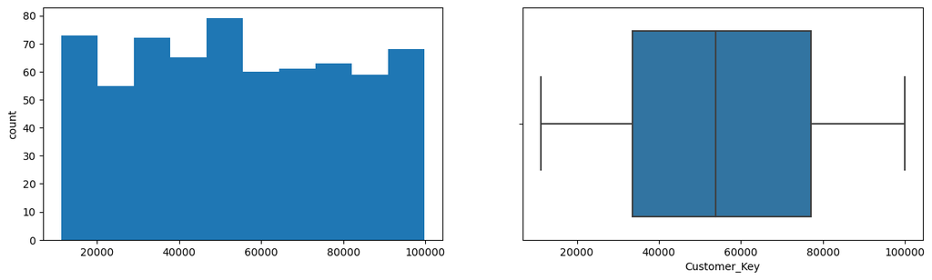

```
Avg_Credit_Limit
Skew : 2.21
```

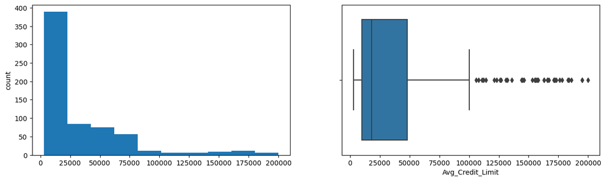

```
Total_Credit_Cards
Skew : 0.16
```

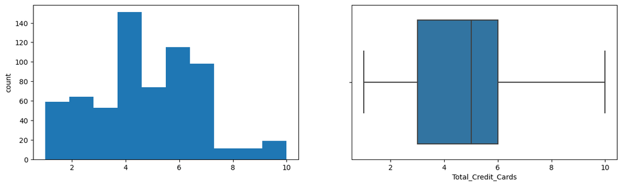

```
Total_visits_bank
Skew : 0.14
```

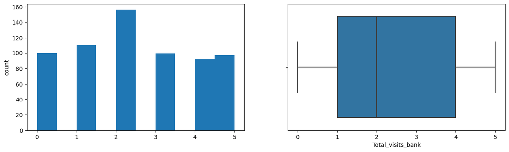

```
Total_visits_online
Skew : 2.23
```

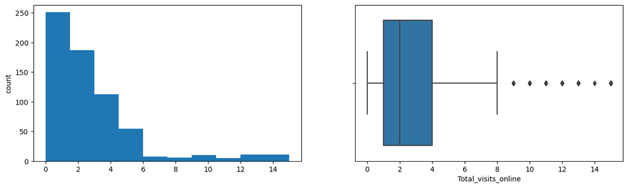

```
Total_calls_made
Skew : 0.65
```

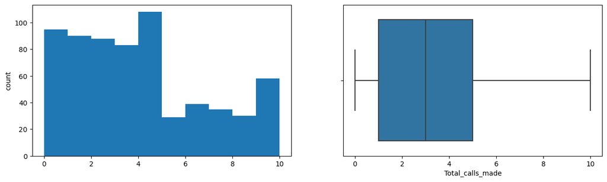

```python
cont_cols = list(data.columns)

for col in cont_cols:

    print(col)

    print('Skew :',round(data[col].skew(),2))

    plt.figure(figsize = (15, 4))

    plt.subplot(1, 2, 1)

    data[col].hist(bins = 10, grid = False)

    plt.ylabel('count')

    plt.subplot(1, 2, 2)

    sns.boxplot(x = data[col])

    plt.show()
```

As we observed earlier, avg_credit_limit has a high skew value with majority of customers on the low end of the limit. And it can be observed from the box plot, that there are several outliers on the high end of the range. The only other variable that has some outliers is the number of online visits per customer. Besided credit_limit, the only variable with high skew is the number of online visits by customers.

Since we observed earlier in the summary of the data, the variables have a very diverse range of values, so we should scale the data to be able to perform feasible analysis.

Now lets look at the heatmap.

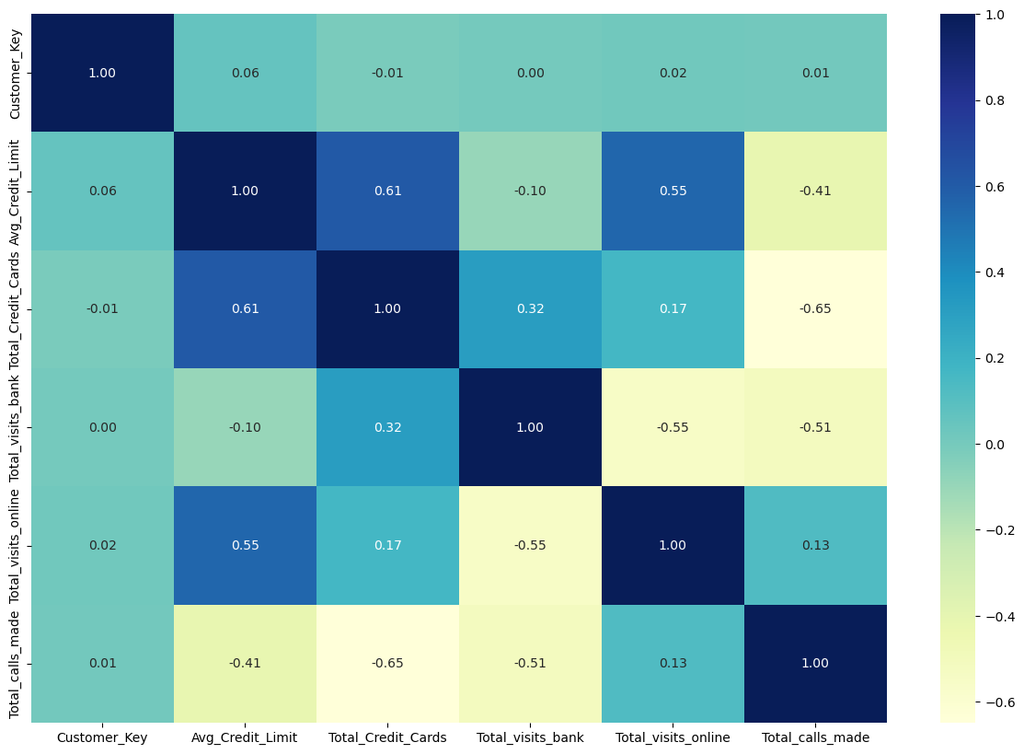

```python
plt.figure(figsize = (15, 10))

sns.heatmap(data.corr(), annot = True, fmt = '0.2f', cmap = "YlGnBu")

plt.show()
```

Most importantly, its a relief to see that there is no correlation between customer_key and any other variables. that means, the data is independant of the individual customers.

There is relatively high positive correlation between credit limit and total_credit_cards which makes sense, people with higher credit limits tend to have more credit cards.

We see a relatively high negative correlation between total_credit_cards and total_calls_made.

We also see some high negative correlation between different modes of contacting the bank, for example customers visiting the bank in person will tend to use other modes of contact slightly less.

data.drop(columns = "Customer_Key", inplace = True) data.head()

#### **Scaling the data**

```python
scaler = StandardScaler()
data_scaled = pd.DataFrame(scaler.fit_transform(data), columns = data.columns)
data_scaled.head()
```

|  | Customer_Key | Avg_Credit_Limit | Total_Credit_Cards | Total_visits_bank | Total_visits_online | Total_calls_made |
| --- | --- | --- | --- | --- | --- | --- |
| 0 | 1.251195 | 1.767076 | -1.241704 | -0.858568 | -0.546642 | -1.257006 |
| 1 | -0.650482 | 0.423440 | -0.780379 | -1.471163 | 2.516526 | 1.884177 |
| 2 | -1.474051 | 0.423440 | 1.064922 | -0.858568 | 0.134062 | 0.139075 |
| 3 | -0.569114 | -0.114014 | 0.142271 | -0.858568 | -0.546642 | 0.139075 |
| 4 | -0.297848 | 1.767076 | 0.603597 | -1.471163 | 3.197230 | -0.209945 |

#### **Applying PCA on scaled data**

```python
# Defining the number of principal components to generate
n = data_scaled.shape[1]

# Finding principal components for the data
pca2 = PCA(n_components = 6, random_state = 1)
data_scaled_pca2 = pd.DataFrame(pca2.fit_transform(data_scaled))

# The percentage of variance explained by each principal component
exp_var1 = pca2.explained_variance_ratio_
```

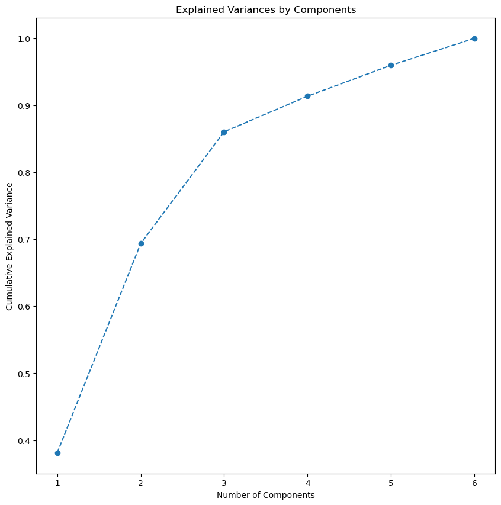

```python
# Visualize the explained variance by individual components
plt.figure(figsize = (10, 10))

plt.plot(range(1, 7), pca2.explained_variance_ratio_.cumsum(), marker = 'o', linestyle = '--')

plt.title("Explained Variances by Components")

plt.xlabel("Number of Components")

plt.ylabel("Cumulative Explained Variance")

plt.show()
```

```python
sum = 0

for ix, i in enumerate(exp_var):

    sum = sum + i

    if(sum>0.85):
        print('Min # of Principal Components to explain atleast 85% variance in the dataset =',ix + 1,)
        break
```

```
Min # of Principal Components to explain atleast 85% variance in the dataset = 3
```

**Finding the coefficients of the first three principal components:**

```python
cols = ['PC1', 'PC2', 'PC3']

pc1 = pd.DataFrame(np.round(pca.components_.T[:, 0:3], 2), index = data_scaled.columns, columns = cols)
pc1
```

|  | PC1 | PC2 | PC3 |
| --- | --- | --- | --- |
| Customer_Key | 0.01 | 0.04 | 1.00 |
| Avg_Credit_Limit | 0.49 | 0.40 | 0.02 |
| Total_Credit_Cards | 0.60 | 0.03 | -0.04 |
| Total_visits_bank | 0.28 | -0.58 | 0.05 |
| Total_visits_online | 0.11 | 0.66 | -0.04 |
| Total_calls_made | -0.56 | 0.22 | 0.01 |

## **K-Means**

We will do this in 3 steps:

1. Initialize a dictionary to store the Sum of Squared Error (SSE) for each K
2. Run for a range of Ks and store SSE for each run
3. Plot the SSE vs K and plot the elbow curve

```python
#importing libraries necessary for K-means clustering analysis

# Importing clustering algorithms
from sklearn.cluster import KMeans

from sklearn.mixture import GaussianMixture

from sklearn_extra.cluster import KMedoids

from sklearn.cluster import AgglomerativeClustering

from sklearn.cluster import DBSCAN

# Silhouette score
from sklearn.metrics import silhouette_score

import warnings
warnings.filterwarnings("ignore")
```

**Now, we are ready to dive in.**

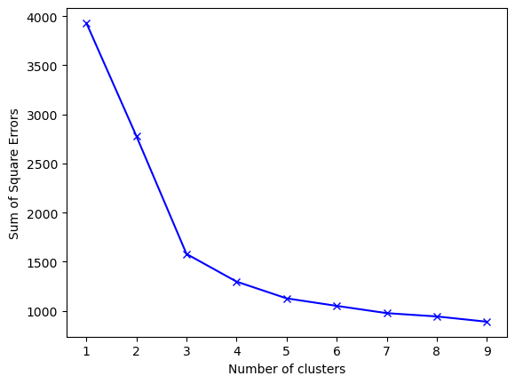

```python
# 1. Creating an empty dictionary to store the SSE for each value of K
sse = {}

# 2. Running a range of Ks from 1 through 9 and storing the SSE value for each K
for k in range(1, 10):
    kmeans = KMeans(n_clusters = k, random_state = 1, n_init = "auto").fit(data_scaled)

    sse[k] = kmeans.inertia_

# 3. Plotting Elbow plot
plt.figure()

plt.plot(list(sse.keys()), list(sse.values()), 'bx-')

plt.xlabel("Number of clusters")

plt.ylabel("Sum of Square Errors")

plt.show()
```

- Interpret the above elbow plot and state the reason for choosing the particular value of K
- Fit the K-means algorithms on the pca components with the number of clusters for the chosen value of K

We observed from the plot above, that the elbow is clearly visible when cluster count is 3. After 3, the curve drops almost evenly. So lets pick 3 as a reasonable number of clusters.

```python
kmeans = KMeans(n_clusters = 3, random_state = 1, n_init = 'auto')

kmeans.fit(data_scaled)

# Adding predicted labels to the original data and the scaled data
data_scaled['KMeans_Labels'] = kmeans.predict(data_scaled)

data['KMeans_Labels'] = kmeans.predict(data_scaled)
```

#### **Create the cluster profiles using the summary statistics and box plots for each label**

```python
# Calculating mean and median of the original data for each label
mean = data.groupby('KMeans_Labels').mean()

median = data.groupby('KMeans_Labels').median()

df_kmeans = pd.concat([mean, median], axis = 0)

df_kmeans.index = ['group_0 Mean', 'group_1 Mean', 'group_2 Mean', 'group_0 Median', 'group_1 Median', 'group_2 Median']

df_kmeans.T
```

[output not shown]

**Cluster2 contains people with highest number of cards and so they also have a highest credit limit. Cluster2 also makes the most online visits. Cluster0 is the opposite of Cluster2 with lowest credit limit, least number of cards. however, Cluster0 makes the most phone calls to the bank. Cluster2 contacts the banks the most but their preferred mode of communication is not calls made, rather they prefer online bank visits.**

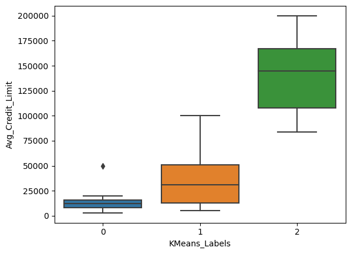

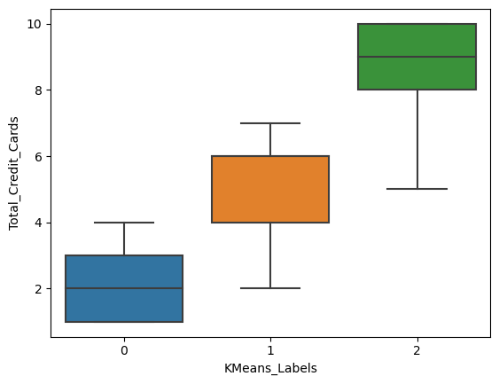

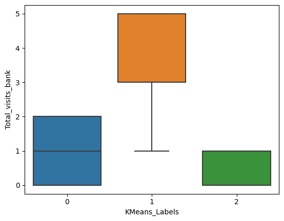

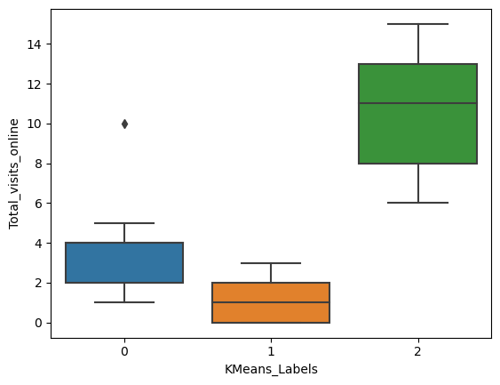

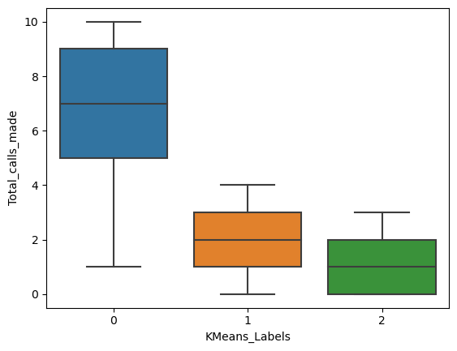

```python
cols_visualise = ['Avg_Credit_Limit', 'Total_Credit_Cards', 'Total_visits_bank', 'Total_visits_online', 'Total_calls_made']

for col in cols_visualise:
    sns.boxplot(x = 'KMeans_Labels', y = col, data = data)
    plt.show()
```

**Cluster Profiles:** Each cluster has their preferred method of contacting the bank; cluster0 preferes phone calls, cluster1 prefers in-person visits while cluster2 prefers online interaction with the bank. Cluster2 has the highest number of credit cards. As the total credit limit of a person is the sum of each of their credit card limits. Thats why we see that cluster2 also has the highest credit limit.

## **Gaussian Mixture Model**

Let's now create clusters using the Gaussian Mixture Model.

- Apply the Gaussian Mixture Model algorithm on the pca components

```python
gmm = GaussianMixture(n_components = 3, random_state = 1)

gmm.fit(data_scaled)

data_scaled['GmmLabels'] = gmm.predict(data_scaled)

data['GmmLabels'] = gmm.predict(data_scaled)
```

#### **Create the cluster profiles using the summary statistics and box plots for each label**

```python
# Calculating the mean and the median of the original data for each label
original_features = ['Avg_Credit_Limit', 'Total_Credit_Cards', 'Total_visits_bank', 'Total_visits_online', 'Total_calls_made']

mean = data.groupby('GmmLabels').mean()

median = data.groupby('GmmLabels').median()

df_gmm = pd.concat([mean, median], axis = 0)

df_gmm.index = ['group_0 Mean', 'group_1 Mean', 'group_2 Mean', 'group_0 Median', 'group_1 Median', 'group_2 Median']

df_gmm[original_features].T
```

|  | group_0 Mean | group_1 Mean | group_2 Mean | group_0 Median | group_1 Median | group_2 Median |
| --- | --- | --- | --- | --- | --- | --- |
| Avg_Credit_Limit | 12174.107143 | 33604.712042 | 140102.040816 | 12000.0 | 31000.0 | 145000.0 |
| Total_Credit_Cards | 2.410714 | 5.505236 | 8.775510 | 2.0 | 6.0 | 9.0 |
| Total_visits_bank | 0.933036 | 3.494764 | 0.591837 | 1.0 | 3.0 | 1.0 |
| Total_visits_online | 3.553571 | 0.976440 | 10.979592 | 4.0 | 1.0 | 11.0 |
| Total_calls_made | 6.870536 | 2.005236 | 1.102041 | 7.0 | 2.0 | 1.0 |

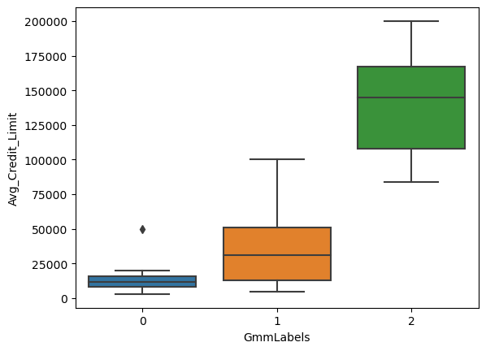

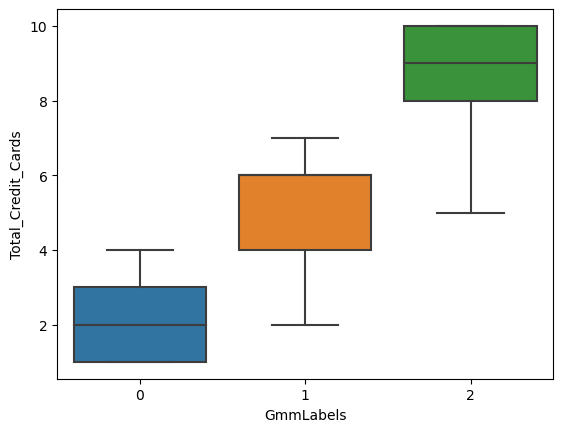

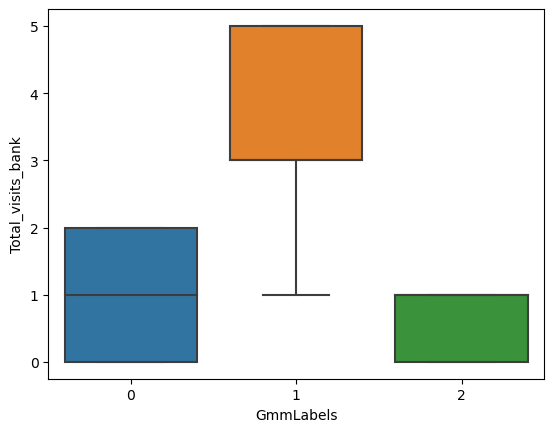

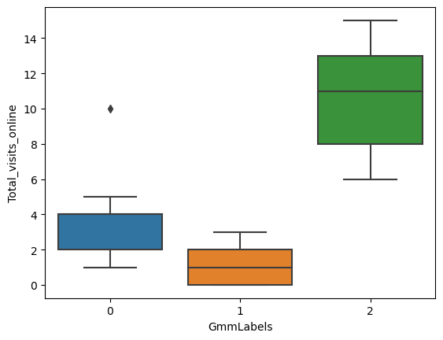

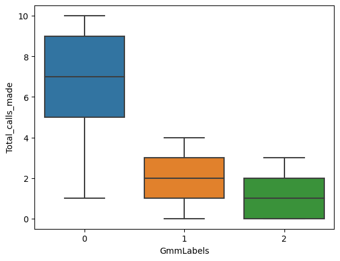

```python
cols_visualise = ['Avg_Credit_Limit', 'Total_Credit_Cards', 'Total_visits_bank', 'Total_visits_online', 'Total_calls_made']

for col in cols_visualise:
    sns.boxplot(x = 'GmmLabels', y = col, data = data)

    plt.show()
```

**CLUSTER PROFILE:** data looks similar to K-means clustering. See below.

#### **Compare the clusters from both algorithms - K-means and Gaussian Mixture Model**

**Comparing Clusters:** **Looking at the description table, the results of the description table and the box plots are exactly the same. so GMM and K-means are both capturing the same information because their techniques are the same and for the given nature of the data, either techinque leads to the same calculations.**

## **K-Medoids**

- Apply the K-Medoids clustering algorithm on the pca components

```python
kmedo = KMedoids(n_clusters = 3, random_state = 1)

kmedo.fit(data_scaled)

data_scaled['kmedoLabels'] = kmedo.predict(data_scaled)

data['kmedoLabels'] = kmedo.predict(data_scaled)
```

```python
original_features = ['Avg_Credit_Limit', 'Total_Credit_Cards', 'Total_visits_bank', 'Total_visits_online', 'Total_calls_made']

mean = data.groupby('kmedoLabels').mean()

median = data.groupby('kmedoLabels').median()

df_kmedoids = pd.concat([mean, median], axis = 0)

df_kmedoids.index = ['group_0 Mean', 'group_1 Mean', 'group_2 Mean', 'group_0 Median', 'group_1 Median', 'group_2 Median']

df_kmedoids[original_features].T
```

|  | group_0 Mean | group_1 Mean | group_2 Mean | group_0 Median | group_1 Median | group_2 Median |
| --- | --- | --- | --- | --- | --- | --- |
| Avg_Credit_Limit | 12172.727273 | 82275.00000 | 23952.727273 | 12000.0 | 68000.0 | 18000.0 |
| Total_Credit_Cards | 2.381818 | 6.63750 | 5.407273 | 2.0 | 7.0 | 6.0 |
| Total_visits_bank | 0.918182 | 2.04375 | 3.796364 | 1.0 | 2.0 | 4.0 |
| Total_visits_online | 3.568182 | 4.11250 | 0.960000 | 4.0 | 2.0 | 1.0 |
| Total_calls_made | 6.922727 | 1.81250 | 1.985455 | 7.0 | 2.0 | 2.0 |

#### **Create cluster profiles using the summary statistics and box plots for each label**

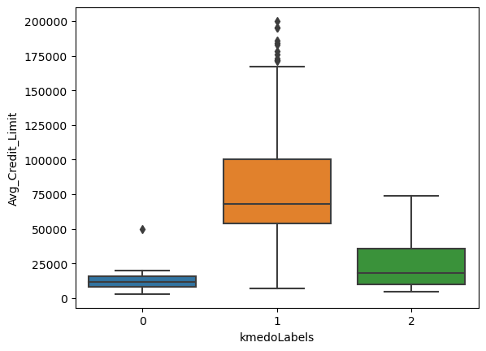

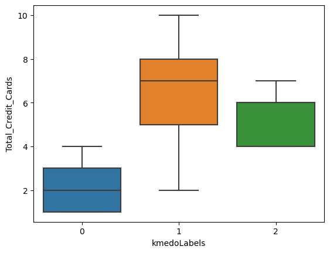

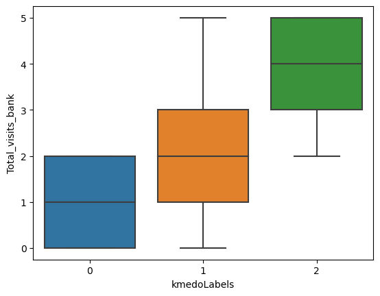

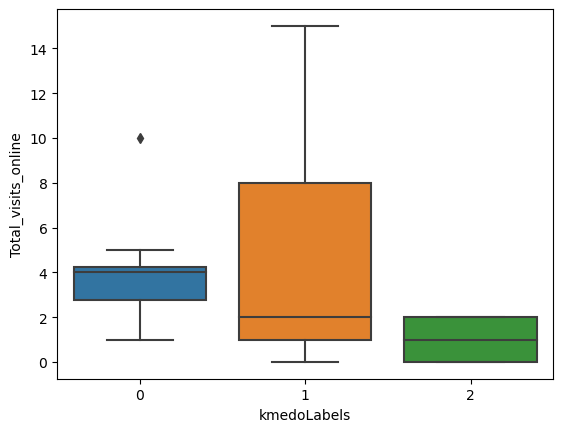

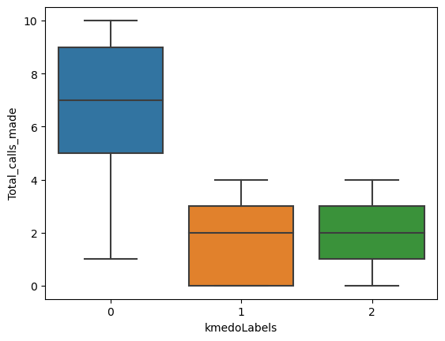

```python
for col in cols_visualise:
    sns.boxplot(x = 'kmedoLabels', y = col, data = data)

    plt.show()
```

**Cluster Profiles:Significant number of outliers detected in Average_credit_limit**

#### **Compare the clusters from K-Means and K-Medoids**

**Comparing Clusters:_K-medoid found a lot of outliers on the high end for the average_Credit_limit. K-means was not able to find this. **__****

## **Conclusions and Business Recommendations**

Customers in Group0 with the most number of phone calls to the bank tend to have the lowest number of credit cards. Which leads me to believe that over the phone customer service needs to improve its performance. Which will perhaps, encourage this set of customers to acquire more credit cards and add to the business of the bank. Or may be they need to be encouraged to visit the bank in person or online to increase their satisfaction level and therefore increase the business with the bank.